# Problem_1

```r
# libraries used
require(igraph, quietly = TRUE)
require(latex2exp, quietly = TRUE )
require(knitr, quietly = TRUE )
require(progress, quietly = TRUE )
require(kableExtra, quietly = TRUE )
set.seed(420)
```

# Social Networks and Online Markets, Homework 1

### Author: Christian Buda

# Problem 1

# Implementations

## Erdős–Rènyi random graph

Let’s start by implementing a basic implementation of this model:

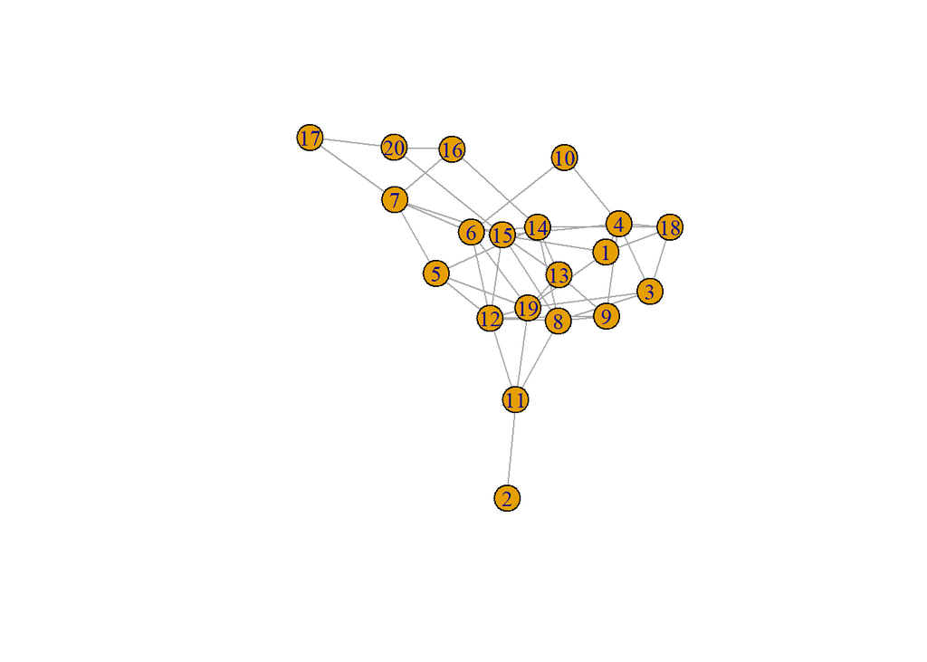

```r
generate_ER_graph = function(n,p) {
  # this function generates an erdos-renyi graph
  # with n nodes and edge probability p

  if (p < 0 | p > 1) stop("p must be in [0,1]")

  # initialize edge list
  edge_list = data.frame(x = numeric(0), y = numeric(0))

  # progressive number of edges
  edge_count = 1

  # randomly generate the edge list
  for (i in 1:(n-1)) {
    for (j in (i + 1):n) {

      if (runif(1) <= p) {
        edge_list[edge_count,] = c(i,j)
        edge_count = edge_count + 1
      }

    }
  }

  # create graph
  g = graph_from_data_frame(edge_list, directed = FALSE, vertices = data.frame(name = 1:n))
  return(g)
}

plot(generate_ER_graph(20, 0.2))
```

This implementation is really slow; to make it quicker, we start by noting that the total number of edges in this model is distributed as a binomial with $N = \frac{n(n-1)}{2}$ and probability $p$. Because of this, an equivalent approach to the classical $G_{n,p}$ is to sample a random number $k$ according to this distribution, and then sample $k$ edges from the list of all possible edges.

To sample from the list of all possible edges without actually creating this list (which can be expensive), we need a way to index them; consider the following adjacency matrix:
$$\begin{pmatrix}
- & - & - & -\\
0 & - & - & -\\
1 & 2 & - & -\\
3 & 4 & 5 & -
\end{pmatrix}$$
Here each entry represents an edge (the diagonal is not considered because we are not allowing for self loops, and, since the graph is undirected, only the lower half of the matrix is shown), and the number in each entry is the index of the corresponding edge.

It is easy to see that, given $i\in\{1,2,\dots,n-1\}$ index of the rows, and $j\in\{0,1,\dots,i-1\}$, the index corresponding to entry $(i,j)$ is given by $\frac{i(i-1)}{2}+j$. We want to invert this relationship; to do this, we start by noting that, given $n$ index of an edge, the corresponding row is given by $i = \max\{k|\frac{k(k-1)}{2}\leq n\}$. By solving the equation $k^2-k-2n=0$ (by taking the rightmost solution) we get $k^* = \frac{1+\sqrt{1+8n}}{2}$, from which we get our solution $i = \lfloor k^*\rfloor = \lfloor \frac{1+\sqrt{1+8n}}{2} \rfloor$, and then the column index is just found as $j=n-\frac{i(i-1)}{2}$. We are now ready to implement the function that will generate our graphs.

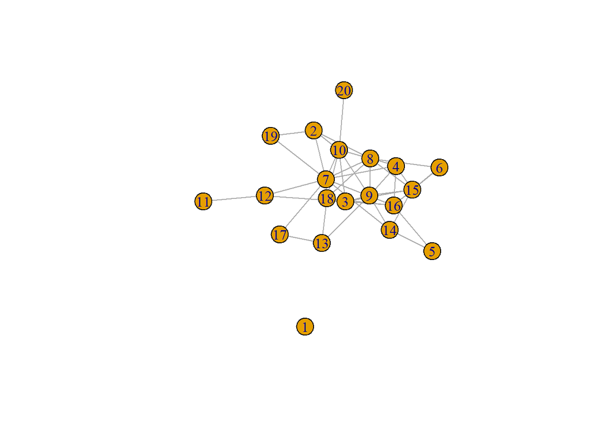

```r
generate_ER_graph_fast = function(n,p) {
  # this function generates an erdos-renyi graph
  # with n nodes and edge probability p

  if (p < 0 | p > 1) stop("p must be in [0,1]")

  num_edges = rbinom(1, n*(n-1)/2, p)

  if (p<=0.5) {
    sampled_edges = sample(0:((n*(n-1)/2)-1), size = num_edges)
  } else {
    # if p>0.5 it is easier to sample the non existing edges
    sampled_edges = sample(1:(n*(n-1)/2), size = n*(n-1)/2 - num_edges)
    sampled_edges = (0:((n*(n-1)/2)-1))[-sampled_edges]
  }

  # get source node of each edge
  source = floor((sqrt(8*sampled_edges+1)+1)/2)

  # get target node of each edge
  target = sampled_edges - source*(source-1)/2

  edge_list = matrix(0, ncol = 2, nrow = num_edges)
  edge_list[,1] = source + 1
  edge_list[,2] = target + 1

  g = graph_from_edgelist(edge_list, directed = FALSE)

  # it is possible that some of the last nodes are isolated
  # and do not compare in the edge list, so we add them by and if needed
  g = add_vertices(g, n-length(V(g)))

  return(g)
}


plot(generate_ER_graph_fast(20, 0.2))
```

## Watts–Strogatz model

As before, we start with the naive implementation:

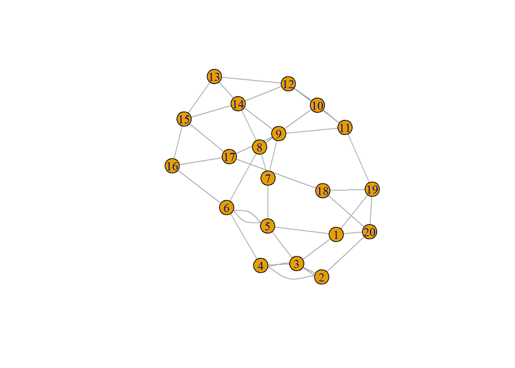

```r
generate_WS_graph = function(n, nei, beta) {
  # this function generates a watts-strogatz small world graph
  # with n nodes, nei initial neighbours for each node, and rewiring probability beta

  if (nei%%2 != 0) stop("nei needs to be even")
  if (nei >= n-1) stop("nei needs to be less than n-1")
  if (beta < 0 | beta > 1) stop("beta must be in [0,1]")

  # to easily handle node numbers that go over n
  format_node = function(node,n) (node-1)%%n + 1

  # to find the right neighbours of a node in a regular ring with nei neighbours
  right_neighbours = function(node, nei, n) format_node(node+1:nei, n)

  # initialize edge list
  edge_list = data.frame(x = numeric(0), y = numeric(0))

  # generate edge list for a regular ring graph
  # by stacking the edges corresponding to the rightneighbors of each node
  for (i in 1:n) {
    edge_list = rbind(edge_list, data.frame(x = rep(i, nei/2), y = right_neighbours(i, nei/2, n)))
  }

  # rewire some of the edges
  for (i in 1:nrow(edge_list)) {

    if (runif(1) <= beta) {
      edge_list[i,2] = sample((1:n)[-edge_list[i,1]], size = 1)
    }

  }

  # create graph
  g = graph_from_data_frame(edge_list, directed = FALSE, vertices = data.frame(name = 1:n))
  return(g)
}


plot(generate_WS_graph(20,4,0.3))
```

To make this faster, we use the same trick as before, extracting the number of rewired edges beforehand, and then extracting the edges to rewire as a random sample of fixed size from the list of all possible edges. Since the graph is pre-existing here, we just rewire some of the existing edges (being careful not to create self-loops).

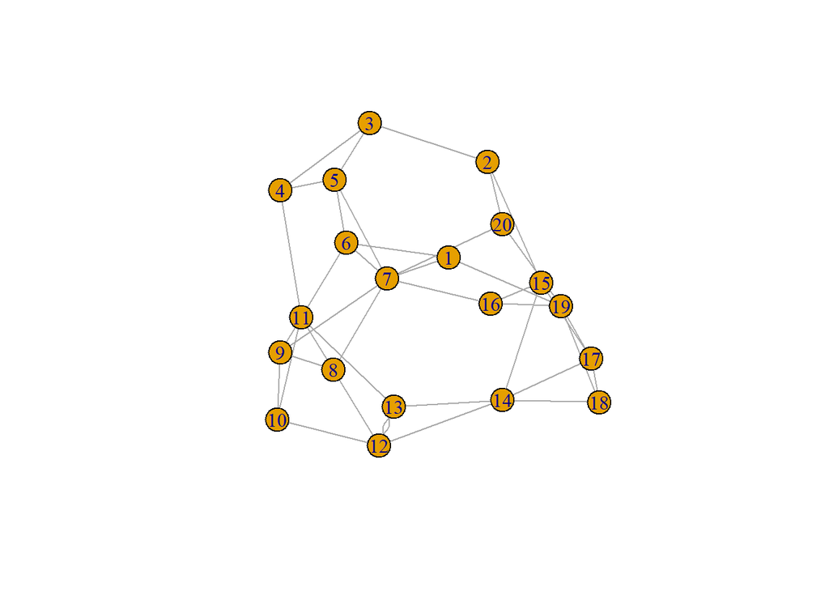

```r
generate_WS_graph_better = function(n, nei, beta) {
  # this function generates a watts-strogatz small world graph
  # with n nodes, nei initial neighbours for each node, and rewiring probability beta

  if (nei%%2 != 0) stop("nei needs to be even")
  if (nei >= n-1) stop("nei needs to be less than n-1")
  if (beta < 0 | beta > 1) stop("beta must be in [0,1]")


  # initialize edge list
  edge_list = matrix(0, ncol = 2, nrow = n*nei/2)

  # here we generate the edge list for a ring graph
  # by stacking the edges corresponding to the rightneighbors of each node
  edge_list[,1] = rep(1:n, rep(nei/2, n))                # source nodes (nei/2 for each node)
  edge_list[,2] = (edge_list[,1] + 0:(nei/2 - 1))%%n + 1 # right neighbors of each source node

  # sample the number of edges to rewire
  num_edges = rbinom(1, n*nei/2, beta)
  # sample the edges to rewire
  sampled_edges = sample(1:(n*nei/2), size = num_edges)

  # rewire each sampled edge, being careful not to create self loops
  find_new_target = function(source) sample((1:n)[-source], size = 1)
  edge_list[sampled_edges,2] = sapply(edge_list[sampled_edges,1], find_new_target)

  # create graph
  g = graph_from_edgelist(edge_list, directed = FALSE)
  return(g)
}


plot(generate_WS_graph_better(20,4,0.3))
```

We can make this a bit faster by “batching” the sampling of each to-be-rewired edge based on the source node. In this way it is much easier to make sure that no self-loops will be created (even though they are not important if $n$ is large enough).

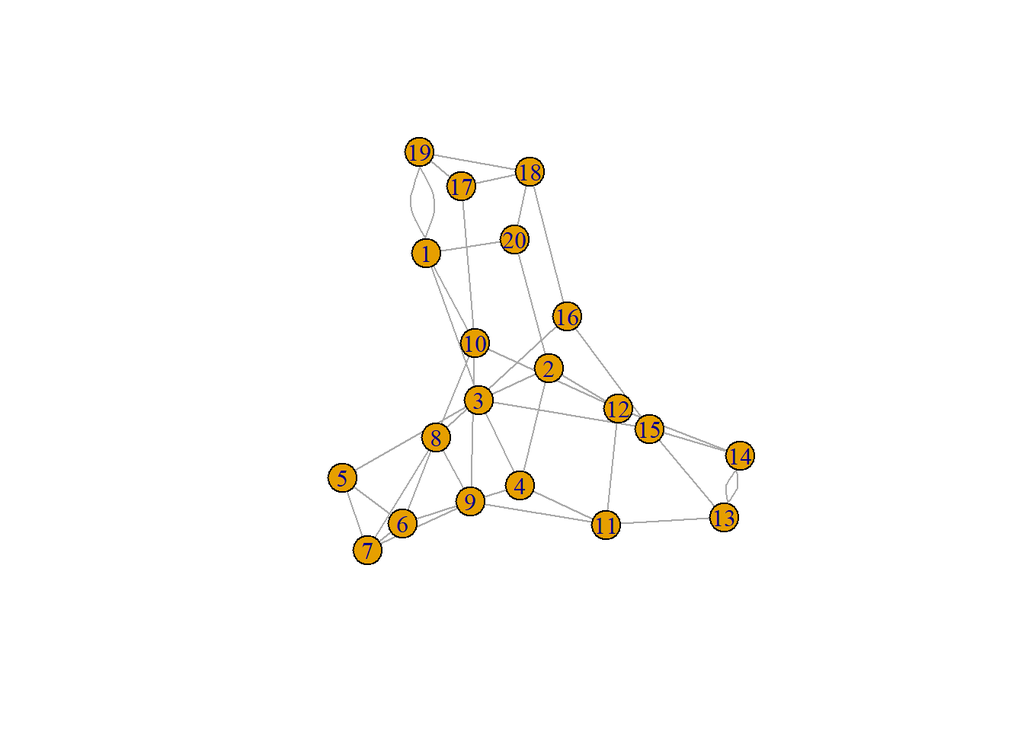

```r
generate_WS_graph_fast = function(n, nei, beta) {
  # this function generates a watts-strogatz small world graph
  # with n nodes, nei initial neighbours for each node, and rewiring probability beta

  if (nei%%2 != 0) stop("nei needs to be even")
  if (nei >= n-1) stop("nei needs to be less than n-1")
  if (beta < 0 | beta > 1) stop("beta must be in [0,1]")


  # initialize edge list
  edge_list = matrix(0, ncol = 2, nrow = n*nei/2)

    # here we generate the edge list for a ring graph
  # by stacking the edges corresponding to the rightneighbors of each node
  edge_list[,1] = rep(1:n, rep(nei/2, n))                # source nodes (nei/2 for each node)
  edge_list[,2] = (edge_list[,1] + 0:(nei/2 - 1))%%n + 1 # right neighbors of each source node

  # sample how many neighbors are rewired for each of the nodes
  edge_per_node = rbinom(n, nei/2, beta)

  # for each source node sample which edge to rewire,
  # done by sampling which right-neighbor which the edge is connected to
  # (indexing them as the index of the corresponding edge in edge_list)
  sample_edges = function(source, size) sample(1:(nei/2), size = size) + (source-1)*nei/2
  edge_to_rewire = unlist(mapply(sample_edges, 1:n, edge_per_node))

  # rewire the selected edges to a new random target node
  rewire = function(source, num_edges) sample((1:n)[-source], size = num_edges, replace = TRUE)
  edge_list[edge_to_rewire, 2] = unlist(mapply(rewire, 1:n, edge_per_node))

  # create graph
  g = graph_from_edgelist(edge_list, directed = FALSE)
  return(g)
}

plot(generate_WS_graph_fast(20,4,0.3))
```

## Barabàsi–Albert model

As before, the naive approach:

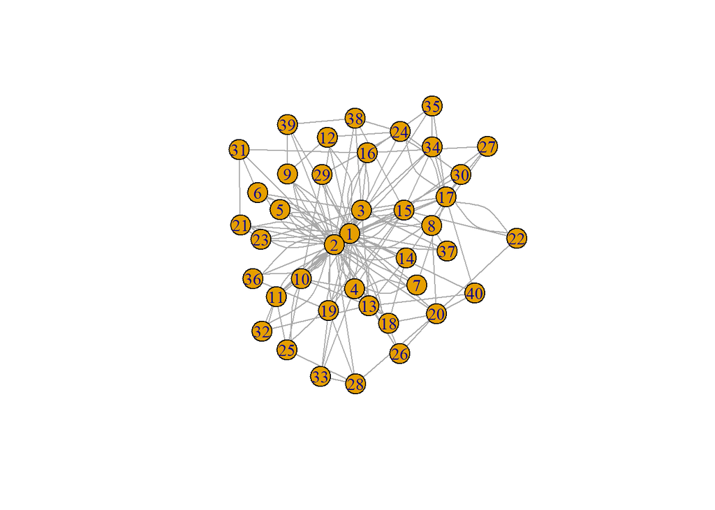

```r
generate_BA_graph = function(n, l) {
  # this function generates a barabasi-albert small world graph
  # with n nodes, and l entrance edges for each node

  # initialize edge list with the source node
  # and with the edges between the first 2 nodes
  edge_list = matrix(1, ncol = 2, nrow = n*l)

  edge_list[,1] = (0:(l*n - 1))%/%l + 1   # all source nodes, each appearing l times
  edge_list[1:l,2] = 2                    # target nodes init

  # initialize degree values for each node
  degree_ = rep(0,n)
  degree_[c(1,2)] = 2*l

  # in each time step we connect a new node
  for (i in 3:n) {

    # select nodes randomly based on the current degree values
    sampled_nodes = sample(1:(i-1), size = l, replace = TRUE, prob = degree_[1:(i-1)]/(2*l*(i-1)))

    # add edges to the edge list
    edge_list[(l*(i-1) + 1):(i*l),2] = sampled_nodes

    # update degree values for the previously inserted nodes
    degree_[1:(i-1)] = degree_[1:(i-1)] + table(factor(sampled_nodes, 1:(i-1)))

    # update degree values for the new node
    degree_[i] = l
  }

  # create graph
  g = graph_from_edgelist(edge_list, directed = FALSE)
  return(g)
}

plot(generate_BA_graph(40,4))
```

Previously, we extracted the target nodes (according to preference), and then updated the degree distribution, now we do the opposite. It turns out this is much faster to do. The trick is always to note that sampling nodes according to preference is like sampling degrees according to a multinomial distribution (and then the increment in degree is the number of edges that each node won).

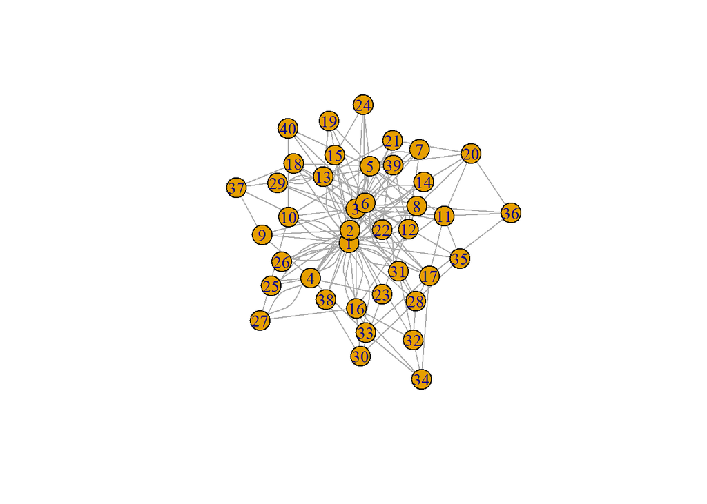

```r
generate_BA_graph_fast = function(n, l) {
  # this function generates a barabasi-albert small world graph
  # with n nodes, and l entrance edges for each node

  # initialize edge list with the source node
  # and with the edges between the first 2 nodes
  edge_list = matrix(1, ncol = 2, nrow = n*l)

  edge_list[,1] = rep(1:n, rep(l,n))
  edge_list[1:l,2] = 2


  # initialize degree values for each node
  degree_ = rep(l,n)
  degree_[c(1,2)] = 2*l

  # in each time step we connect a new node
  for (i in 3:n) {

    # extract the increment in degree distribution
    sampled_degrees = rmultinom(1, l, prob = degree_[1:(i-1)]/(2*l*(i-1)))

    # connect the new node to the sampled sources according to their increment in degree
    edge_list[(l*(i-1) + 1):(i*l),2] = rep(1:(i-1), sampled_degrees)

    # update degree values for the previously inserted nodes
    degree_[1:(i-1)] = degree_[1:(i-1)] + sampled_degrees
  }

  # create graph
  g = graph_from_edgelist(edge_list, directed = FALSE)
  return(g)
}

plot(generate_BA_graph_fast(40,4))
```

# Analisys

We will fix $n=10000$ for all graphs to avoid long computation timings.

```r
n = 10000
```

## Erdős–Rènyi random graph

Having fixed $n$, we vary $p$ in the following grid (we avoid high values of $p$ because they make the computations really slow):

```
##  [1] 0.000010000 0.000020000 0.000030000 0.000040000 0.000050000 0.000060000
##  [7] 0.000070000 0.000080000 0.000090000 0.000100000 0.000110000 0.000120000
## [13] 0.000130000 0.000140000 0.000150000 0.000160000 0.000170000 0.000180000
## [19] 0.000190000 0.000200000 0.001000000 0.001441067 0.001881940 0.002322618
## [25] 0.002763102 0.009210340 0.019210340 0.029210340 0.039210340 0.049210340
## [31] 0.059210340 0.069210340 0.079210340 0.089210340 0.099210340 0.200000000
## [37] 0.300000000 0.400000000 0.500000000 0.600000000 0.700000000
```

And now we compute all the graphs:

```r
diam = rep(0, length(p_vec))
ccoef = rep(0, length(p_vec))
lccsize = rep(0, length(p_vec))
g_vec = list()


for (i in 1:(length(p_vec))) {
  p = p_vec[i]

  g = generate_ER_graph_fast(n,p)

  g_vec = append(g_vec, list(degree(g)))

  diam[i] = diameter(g)

  ccoef[i] = transitivity(g, type = "average")

  lccsize[i] = max(clusters(g)$csize)/n
}
```

We start by showing some of the degree distribution histograms, where we superimposed the theoretical binomial density to each of the graphs.

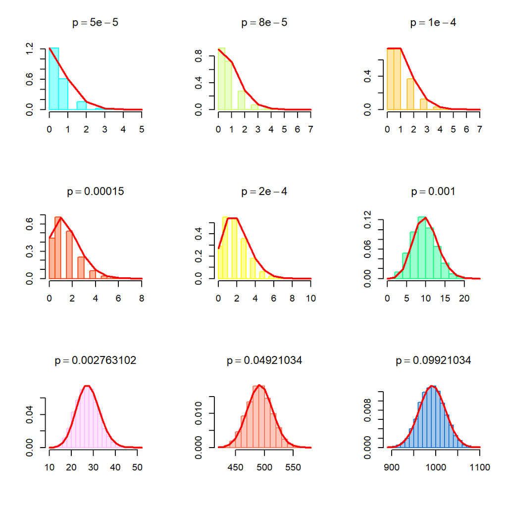

As we can see, the theoretical density is in perfect agreement with the findings. We can also note how, for small values of $p$ the distribution is highly skewed towards $0$, as soon as $p$ gets high enough though, the distribution becomes very symmetric and with high mean value.

And here are the diameter, clustering coefficient and size of the largest connected component in this range of probability values:

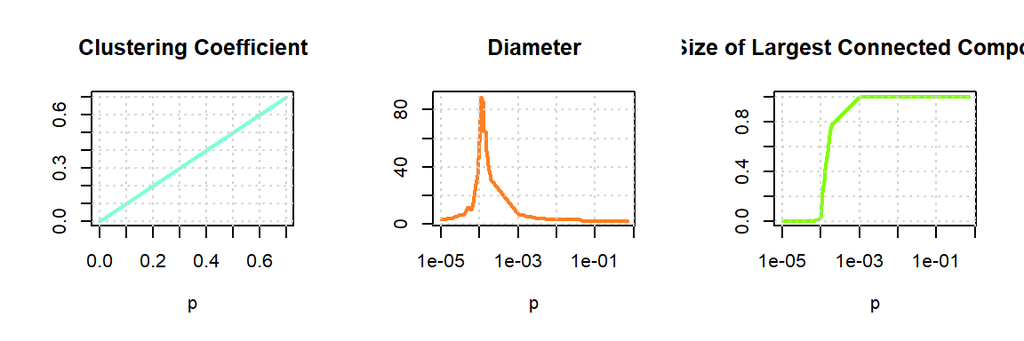

Here is a numerical summary of the results:

Results for the Erdős–Rènyi model

| $p$ | Diameter | Clustering Coefficient |
| --- | --- | --- |
| 0.0000100 | 3 | 0.0000000 |
| 0.0000200 | 4 | 0.0000000 |
| 0.0000300 | 6 | 0.0000000 |
| 0.0000400 | 7 | 0.0000000 |
| 0.0000500 | 12 | 0.0000000 |
| 0.0000600 | 10 | 0.0000000 |
| 0.0000700 | 15 | 0.0000000 |
| 0.0000800 | 28 | 0.0000000 |
| 0.0000900 | 34 | 0.0000000 |
| 0.0001000 | 58 | 0.0000000 |
| 0.0001100 | 89 | 0.0004687 |
| 0.0001200 | 86 | 0.0004123 |
| 0.0001300 | 65 | 0.0000000 |
| 0.0001400 | 65 | 0.0000000 |
| 0.0001500 | 51 | 0.0000000 |
| 0.0001600 | 47 | 0.0000000 |
| 0.0001700 | 41 | 0.0001639 |
| 0.0001800 | 37 | 0.0003765 |
| 0.0001900 | 35 | 0.0002656 |
| 0.0002000 | 31 | 0.0000000 |
| 0.0010000 | 7 | 0.0010219 |
| 0.0014411 | 6 | 0.0014218 |
| 0.0018819 | 5 | 0.0020211 |
| 0.0023226 | 5 | 0.0023141 |
| 0.0027631 | 4 | 0.0027433 |
| 0.0092103 | 3 | 0.0092222 |
| 0.0192103 | 3 | 0.0192456 |
| 0.0292103 | 3 | 0.0292218 |
| 0.0392103 | 3 | 0.0391668 |
| 0.0492103 | 2 | 0.0491960 |
| 0.0592103 | 2 | 0.0592649 |
| 0.0692103 | 2 | 0.0692131 |
| 0.0792103 | 2 | 0.0792228 |
| 0.0892103 | 2 | 0.0893097 |
| 0.0992103 | 2 | 0.0992195 |
| 0.2000000 | 2 | 0.2000457 |
| 0.3000000 | 2 | 0.2999390 |
| 0.4000000 | 2 | 0.4000089 |
| 0.5000000 | 2 | 0.5001199 |
| 0.6000000 | 2 | 0.5999276 |
| 0.7000000 | 2 | 0.6999063 |

## Watts–Strogatz model

We now have two parameters to explore, we will vary $\beta$ in this range:

```
## [1] 1e-06 1e-04 1e-03 1e-02 1e-01 3e-01 4e-01 6e-01 8e-01
```

And the number of neighbors in this range:

```
## [1]    2    4    8  128  512 2048
```

Here we compute the graph for every possible combination of the two:

```r
diam = matrix(0, ncol = length(beta_vec), nrow = length(nei_vec))
ccoef = matrix(0, ncol = length(beta_vec), nrow = length(nei_vec))
g_vec = list()


for (j in 1:(length(nei_vec))) {
  for (i in 1:(length(beta_vec))) {
    nei = nei_vec[j]
    beta = beta_vec[i]

    g = generate_WS_graph_fast(n,nei,beta)

    g_vec = append(g_vec, list(degree(g)))

    diam[j,i] = diameter(g)

    ccoef[j,i] = transitivity(g, type = "average")
  }
}
```

Here are the degree distributions for each of these graphs:

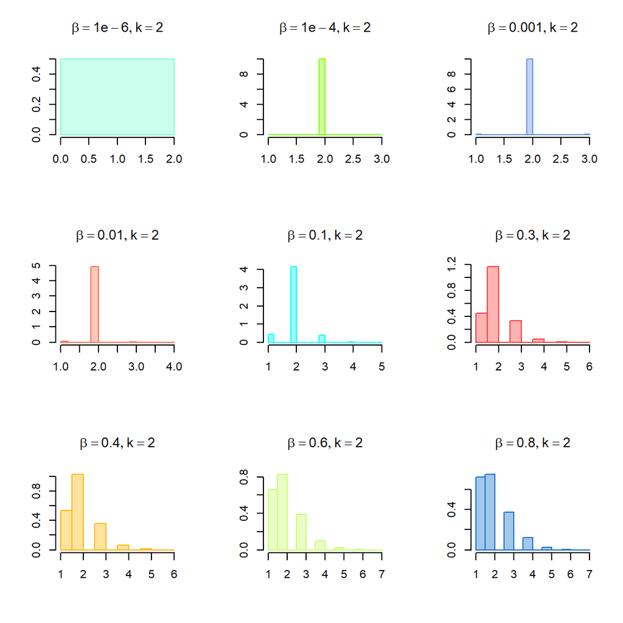

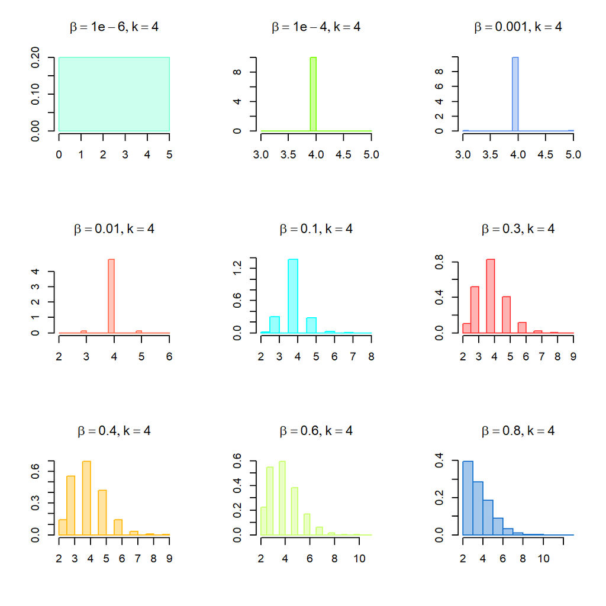

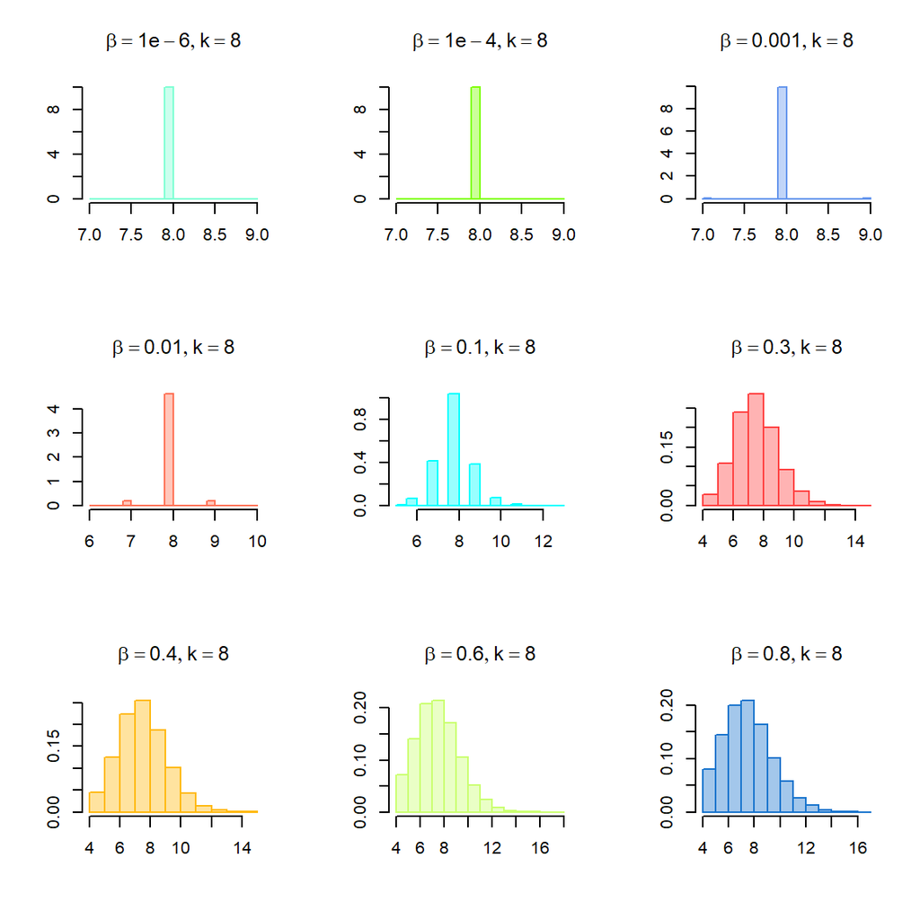

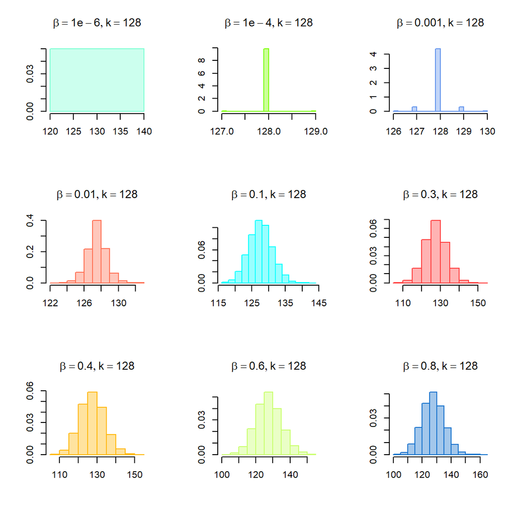

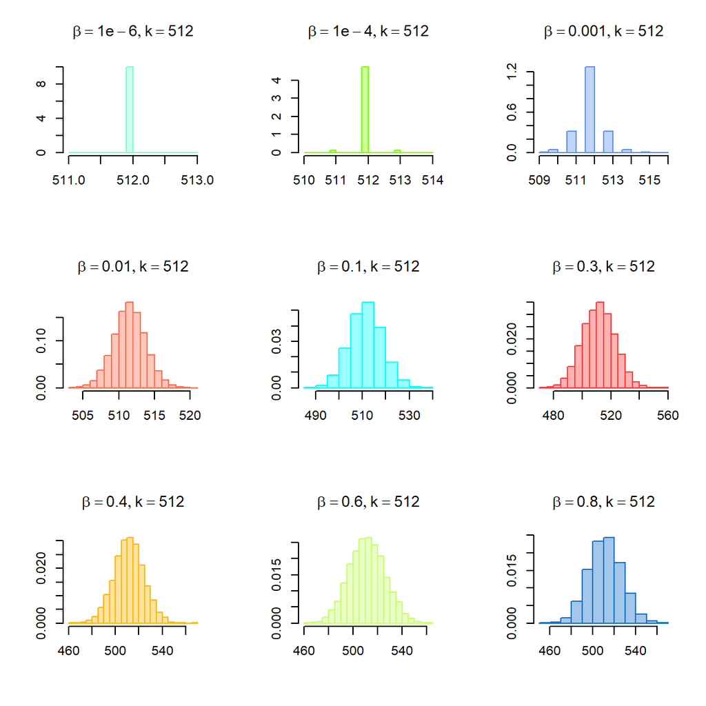

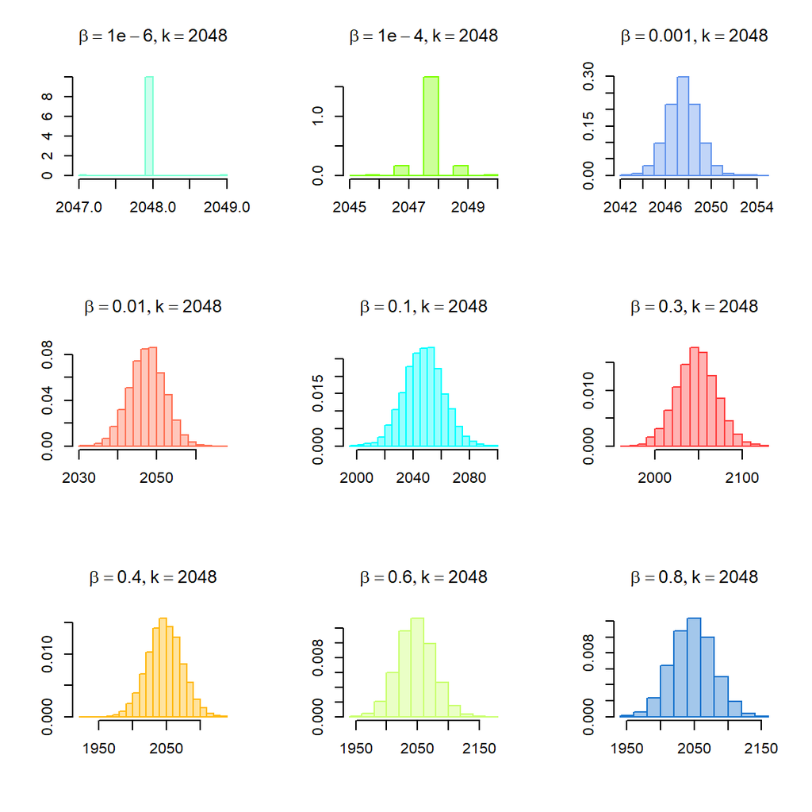

As we can see, for small values of $\beta$, the distribution resembles the one of a ring graph (a Dirac delta), and, as the rewiring probability increases, the distribution starts spreading out and gets closer and closer to the ER random case. Moreover, we can see that increasing $k$ has the effect of speeding up this process, since more and more edges become available for the rewiring.

Here are the diameter and clustering coefficient for each fixed $k$ value:

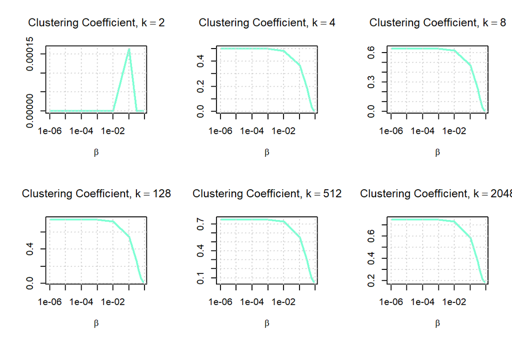

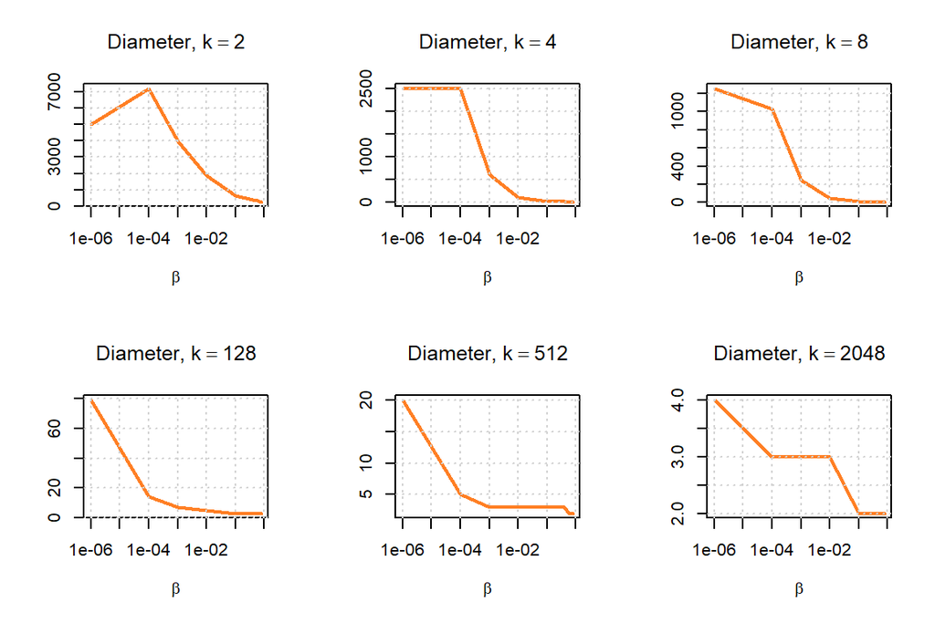

With the exception of the special case $k=2$, we can see that both the diameter, and the clustering coefficient decreases, although the clustering coefficient only drops at significant values of $\beta$, while the diameter drops almost immediately. The case $k=2$ is somewhat special since, before the rewiring, no neighbours are connected with each other (the graph is a perfect ring), so the clustering coefficient is very low (and stays low even for higher values of $beta$, since there are not many edges to rewire); the diameter is initially very high, and for small values of $\beta$ it may happen that the cycle is broken and the diameter briefly gets higher. Meanwhile, the spike in the clustering coefficient is very low, so it may be due to chance. It is also interesting to note that, for high values of $k$, the diameter is already very low, so the decrease can be somewhat slower.

Here is a numerical summary of the results:

Results for the Watts–Strogatz model

| $\beta$ | $k$ | Diameter | Clustering Coefficient |
| --- | --- | --- | --- |
| 1e-06 | 2 | 5000 | 0.0000000 |
| 1e-04 | 2 | 7180 | 0.0000000 |
| 1e-03 | 2 | 3968 | 0.0000000 |
| 1e-02 | 2 | 1888 | 0.0000000 |
| 1e-01 | 2 | 648 | 0.0001642 |
| 3e-01 | 2 | 429 | 0.0000000 |
| 4e-01 | 2 | 402 | 0.0000000 |
| 6e-01 | 2 | 328 | 0.0000000 |
| 8e-01 | 2 | 264 | 0.0000000 |
| 1e-06 | 4 | 2500 | 0.5000000 |
| 1e-04 | 4 | 2500 | 0.4999633 |
| 1e-03 | 4 | 616 | 0.4983933 |
| 1e-02 | 4 | 103 | 0.4838200 |
| 1e-01 | 4 | 25 | 0.3695060 |
| 3e-01 | 4 | 15 | 0.1817808 |
| 4e-01 | 4 | 14 | 0.1163302 |
| 6e-01 | 4 | 12 | 0.0345763 |
| 8e-01 | 4 | 11 | 0.0047476 |
| 1e-06 | 8 | 1250 | 0.6428167 |
| 1e-04 | 8 | 1026 | 0.6427357 |
| 1e-03 | 8 | 241 | 0.6410262 |
| 1e-02 | 8 | 48 | 0.6255983 |
| 1e-01 | 8 | 11 | 0.4736333 |
| 3e-01 | 8 | 8 | 0.2259336 |
| 4e-01 | 8 | 8 | 0.1419300 |
| 6e-01 | 8 | 7 | 0.0423930 |
| 8e-01 | 8 | 7 | 0.0057379 |
| 1e-06 | 128 | 79 | 0.7440945 |
| 1e-04 | 128 | 14 | 0.7438755 |
| 1e-03 | 128 | 7 | 0.7417602 |
| 1e-02 | 128 | 5 | 0.7221329 |
| 1e-01 | 128 | 3 | 0.5451616 |
| 3e-01 | 128 | 3 | 0.2626067 |
| 4e-01 | 128 | 3 | 0.1689756 |
| 6e-01 | 128 | 3 | 0.0589922 |
| 8e-01 | 128 | 3 | 0.0183956 |
| 1e-06 | 512 | 20 | 0.7485311 |
| 1e-04 | 512 | 5 | 0.7483196 |
| 1e-03 | 512 | 3 | 0.7463551 |
| 1e-02 | 512 | 3 | 0.7276699 |
| 1e-01 | 512 | 3 | 0.5567733 |
| 3e-01 | 512 | 3 | 0.2844727 |
| 4e-01 | 512 | 3 | 0.1965324 |
| 6e-01 | 512 | 2 | 0.0926710 |
| 8e-01 | 512 | 2 | 0.0550374 |
| 1e-06 | 2048 | 4 | 0.7496304 |
| 1e-04 | 2048 | 3 | 0.7494634 |
| 1e-03 | 2048 | 3 | 0.7478267 |
| 1e-02 | 2048 | 3 | 0.7318879 |
| 1e-01 | 2048 | 2 | 0.5892300 |
| 3e-01 | 2048 | 2 | 0.3669561 |
| 4e-01 | 2048 | 2 | 0.2968048 |
| 6e-01 | 2048 | 2 | 0.2166586 |
| 8e-01 | 2048 | 2 | 0.1890781 |

## Barabàsi–Albert model

Having fixed $n$, we vary $l$ in the following grid:

```
## [1]    1    2    4   16   32   64  256 1024 2048
```

And now we compute all the graphs:

```r
diam = rep(0, length(l_vec))
ccoef = rep(0, length(l_vec))
g_vec = list()

for (i in 1:(length(l_vec))) {
  l = l_vec[i]

  g = generate_BA_graph_fast(n,l)

  g_vec = append(g_vec, list(degree(g)))

  diam[i] = diameter(g)

  ccoef[i] = transitivity(g, type = "average")
}
```

We start by showing some of the degree distributions (in loglog scale, since we expect a power law).

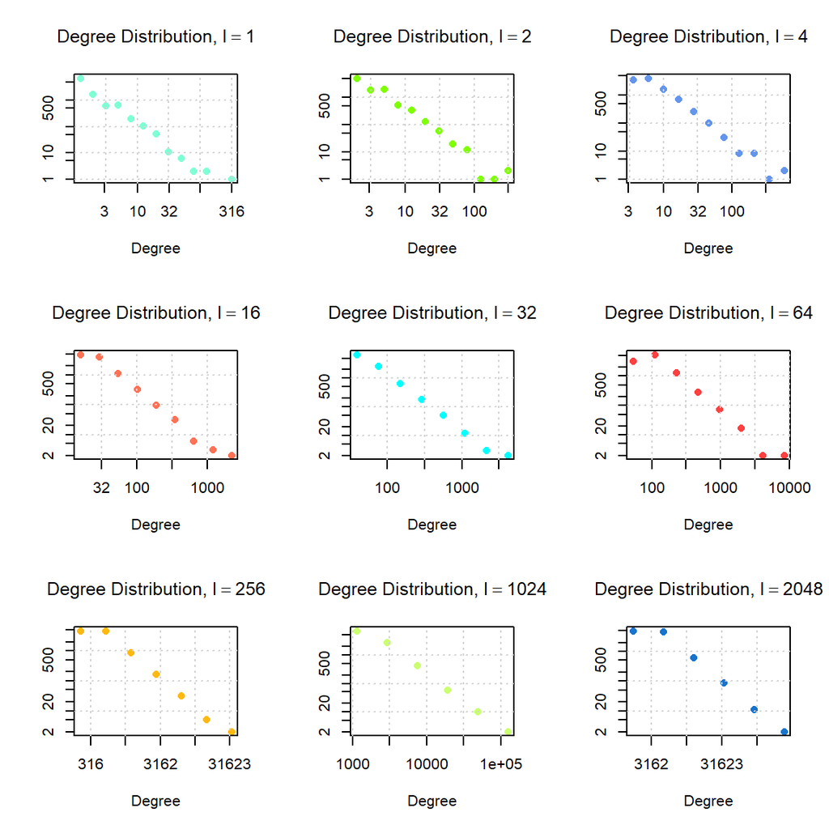

The distributions are clearly asymptotically linear in the loglog space, indicating, indeed, a power law distribution. This pattern is mantained at the various levels of $l$, indicating that changing $l$ only affects the scale at which this phoenomenon happen (it just shifts the distribution on the right in the x-axis).

Here are the diameter and clustering coefficient for the various values of $l$:

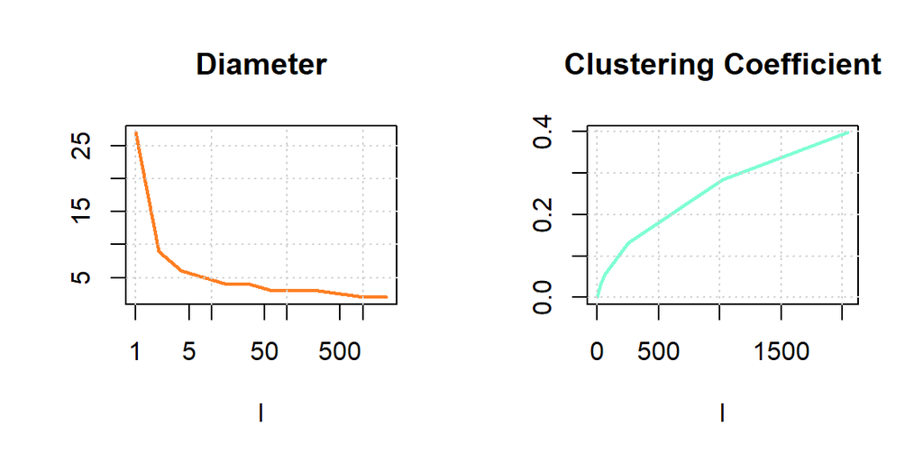

As we could have expected, the diameter of the network rapidly decreases as $l$ increases. The interesting thing is the fact that the diameter is already pretty small at $l=1$, indicating that this decreasing trend is also due to the network structure, and not only to the increase in the number of edges. Meanwhile, the clustering coefficient is slowly increasing, probably due to randomness, since the number of edges for each node is already extremely high; this kind of network structure favors short connections to hubs rather than dense neighborhoods.

Here is a numerical summary of the results:

Results for the Barabàsi–Albert model

| $\ell$ | Diameter | Clustering Coefficient |
| --- | --- | --- |
| 1 | 27 | 0.0000000 |
| 2 | 9 | 0.0053025 |
| 4 | 6 | 0.0086953 |
| 16 | 4 | 0.0224762 |
| 32 | 4 | 0.0360724 |
| 64 | 3 | 0.0572270 |
| 256 | 3 | 0.1323691 |
| 1024 | 2 | 0.2833221 |
| 2048 | 2 | 0.3974513 |